# Urban Big Data Analytics - Lecture 5 Group Session: Spatial data

Andy Hong

July 23, 2019

## Prerequisites

Please locate your `vsp_bigdata` folder under “My Documents” and navigate to `group-session`. Create `05-lecture` folder under the `group-session` folder.

1. For this group session, we will use the Seattle crime database we loaded yesterday.  
   If you have completed the tasks yesterday, you will have the Seattle crime data ready to be loaded into the Exploratory.  
   If you don’t have the Seattle crime database, you will need to download this CSV file separately and load it into Exploratory: [Seattle crime data 2013](http://urbanbigdata.github.io/05-lecture-spatial_data/group-session/seattle_crime_2013.csv)
2. Now, you need to download the US census data to add demographic information: [Seattle Census ACS data 2013](http://urbanbigdata.github.io/05-lecture-spatial_data/group-session/seattle_census_2013.csv)
3. Lastly, you need to download the US census tract GeoJSON file for mapping: [Seattle tract GeoJSON data](http://urbanbigdata.github.io/05-lecture-spatial_data/group-session/seattle_tract.geojson)

## Instruction

### 1. Synopsis

The purpose of this group session is to get you familiar with **data joining** and **spatial data**. There are three steps in this group session. First, you will use the coordinate data (latitude and longitude) to do some cool mapping with Exploratory. To do that, you will filter the data and create a heatmap of crime activities.

Second, you will join the Seattle Census data to the crime data using the common field named `tract`. Then you will explore the data using the `Chart` tool in Exploratory.

Third, you will load the Census tract geojson file and and map other demographic data from the Census.

### 2. Initial preparation

First, open Exploratory and import the Seattle crime data only for the year 2013 using the following code.

```r
library("RSQLite")
library("DBI")

# Define database path
filename = "/Users/[user name]/Documents/vsp_bigdata/group_session/04-lecture/seattle_crime_data.db"
#filename = "C://Users//[user name]//Documents//vsp_bigdata//group_session//04-lecture//seattle_crime_data.db"

# Connect to db
con = dbConnect(drv=RSQLite::SQLite(), dbname=filename)

# Issue a query to read the data
# my_data = dbGetQuery(con, "SELECT * FROM crime")

my_data = dbGetQuery(con, "SELECT Year, Month, SummarizedOffenseDescription, DateReported, DistrictSector, Latitude, Longitude, CensusTract2000 FROM crime WHERE Year = 2013")
```

Now create a new column named `tract` using `mutate` and the the following calculation.

```r
as.numeric(gsub("\\..*", "", CensusTract2000))
```

This calculation extracts only the tract number from the data.  
**Further information for advanced students**: the `gsub` function uses regular expression to filter and replace characters. In this case the regular expression finds all the characters that go after . and replace them with a blank character. For example, 6200.1043 becomes 6200.  
You can read more about this function here: http://stat.ethz.ch/R-manual/R-devel/library/base/html/grep.html

### 3. First part - Mapping crime activities using points data

Now, we are going to map crime activities. Go to `Chart` and choose `Map - Long/Lat` for the type. Exploratory will automatically populate the Longitude and Latitude, but if it doesn’t, choose `Longitude` for Longitude and `Latitude` for Latitude.

You will notice that some coodinates are erronous, so we will need to restrict our data only within the Seattle area using the bounding box as shown below. The correct range of latitude is 47.484 ~ 47.767, and longitude is -122.446 ~ -122.183.

[figure not shown]

Or you can add a custom filter, and copy and paste the following code.

```r
filter(between(Latitude, 47.484, 47.767) & between(Longitude, -122.446, -122.183))
```

There are too many criminal activities in one year, so we will need to filter for one type of crime.

Click `+` and select `Filter`. For the column, choose `SummarizedOffenseDescription` and leave the operator as `equal to` and select `BIKE THEFT` for the value. You can see that the downtown and the university areas have a lot of bike theft incidents.

Now, let’s create a heatmap. Click `+` on your Chart, and Choose `Map - Heatmap`. It automatically creates the heatmap of bike theft. We can clearly see that the bike thefts are concentrated around the downtown and the university areas.

### 4. Second part - Data joining and exploration

For data exploration, we will need to group the data by `census tract`. Go back to one step before we filtered the data for Bike Theft. Click `+` and choose `Group_by` and choose `tract`. `Group_by` is not going to do anything unless we summarize the data. Let’s summarise the data and get the total number of crime by census tract. We can do this by clicking `+` and choose `Summarize` and choose `# Number of rows` for the Column, and give the New column name as `total_crime`.

Next, we will join the Seattle census data to add demographic information to the crime data. Add File Data by using the `+` sign and select `seattle_census_2013.csv` file we downloaded earlier.

Now, go back to the Seattle crime data. We will join the crime data and the census data. But before we do the join, plesae review these three dffierent types of data join.

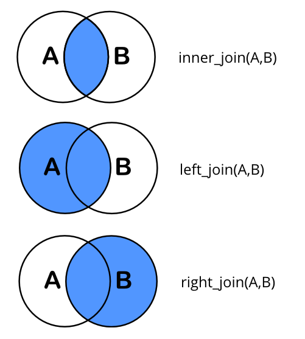

If you are comfortable with the concept of data join, click `+` and select `Join`.  
In the target data frame, choose `seattle_census_2013` and for both the Current Column and Target Column, choose `tract`. We can see that Census data are joined to the Seattle crime data.

Once we joined the data by census tract, we can go to `Chart` and choose `Scatter` for the type. On X Axis, choose `pop_den` and for Y Axis, choose `total_crime`. We can see the relationship between population density and total crime.

We can make the plot fancier by adding a trend line. Click the accordian-style menu next the Y Axis, and click `Trend Line` and choose `Linear Regression` for the type. It shows a beautiful scatter plot with a trend line showing the relationship between population density and crime.

### 5. Third part - Mapping demogrphic characteristics using polygon data

Now that we joined the Census data, we can map our data by census tract. Click `+` on your Chart, and choose `Map - Area` for the type. On the `Area Type`, click the `Setup` button. Click `Add New` and `Add from Local`. From your group session folder, choose `seattle_tract.geojson` file. Close the dialog.

For the Area Type, now we can see that there is `seattle_tract` on the select menu. Choose `seattle_tract`. For the Key Property, scroll all the way down, and choose `tract`. For the Key Column, choose `tract`. Now we can choose any columns in the Color By to show their patterns on the map. For example, choose `total_crime`.

### 6. [Advanced material] Thinking about numerators and denominators

We used `total_crime` as a proxy for indicating the intensity of criminal activities in certain neighborhoods (i.e. census tract). Do you think this is an appropriate measure of criminal activity? How would you adjust for the number of people in the neighborhood? Add this extra step to calculate the new proxy variable, and compare your map using the `total_crime` variable vs. the map using this new variable.

[Hint] Criminal activities in certain neighborhood will be porportional to the number of people living there, so population will be your denominator.

## Publish your data and codes

Once your group session is completed, please publish your data and codes using the following steps.

1. Click the publish button as shown below:

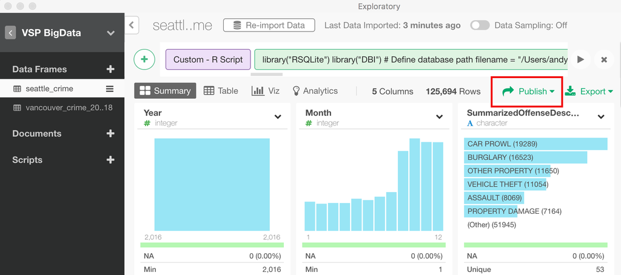

2. Write your title and select options as shown below:

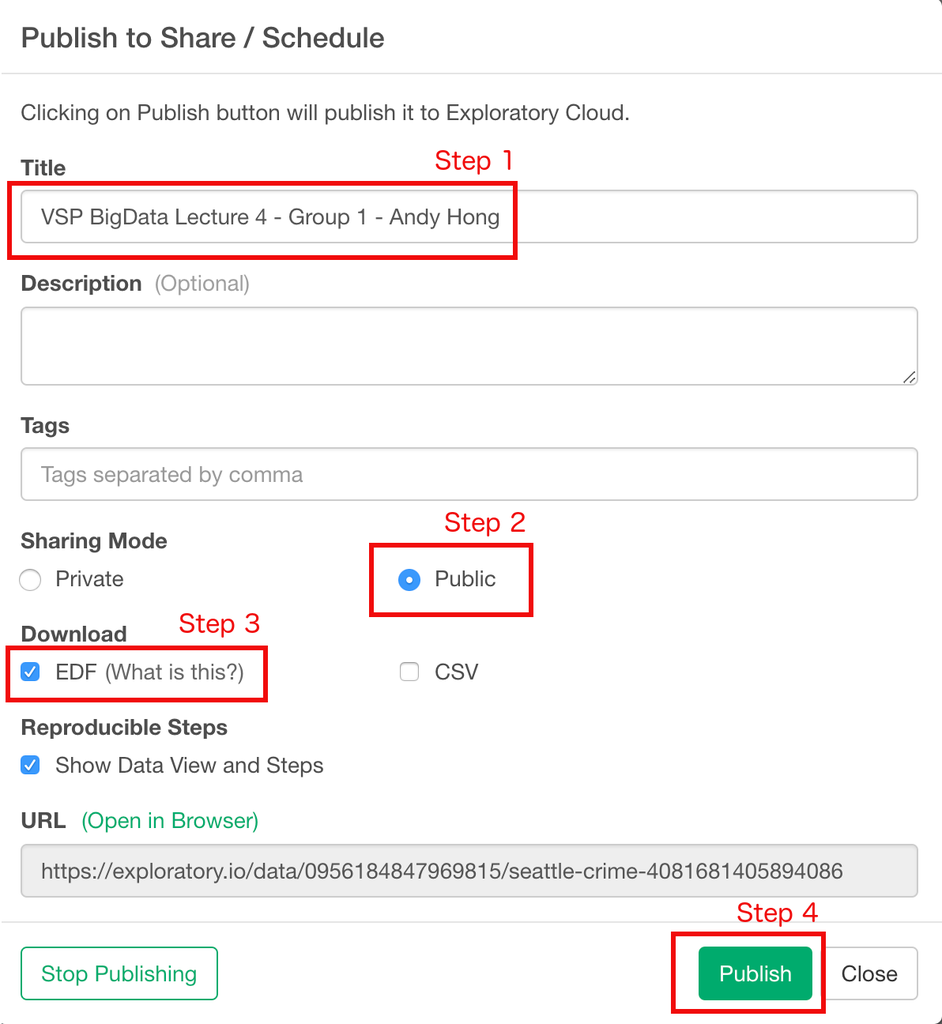

3. Please send the published URL to the course email (urbanbigdata2019@gmail.com).
- **[IMPORTANT]** Please use the following email title format:  
  `VSP BigData [lecture number] - [group number] - [presenter name]`  
  ex), `VSP BigData Lecture 5 - Group 1 - Bill Gates`